# Data Visualization and Reproducible Research.

Bindhu Lasya Nandimandalam

Learn more about me in my bindhulasya.

The following is a sample of products created during the *“Data Visualization and Reproducible Research”* course.

## Project 01

In the `project_01/` folder you can find… *[Through the analysis of the “Motor Vehicle Collisions in New York” dataset, I gained valuable insights into the characteristics and outcomes of motor vehicle accidents. By visualizing the data using bar charts, scatter plots, and treemaps, I effectively communicated the patterns, trends, and relative frequencies of motor vehicle collisions.The analysis highlighted seasonal patterns in collision rates, identified high-collision periods during the day, and shed light on the vehicle types most commonly involved in accidents. These findings can contribute to developing targeted interventions and strategies to improve road safety and reduce motor vehicle collisions.By leveraging the principles of data visualization and design, including appropriate chart selection, clear labeling, color choices, layout, and data integrity, I ensured the visualizations effectively communicated the insights and facilitated easy understanding for the audience.]*

**Sample data visualization:**

*[Motor Vehicle collisions Rate by Month and Year]*

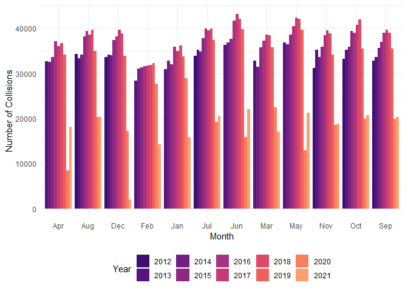

## Project 02

In this project, I explored … *[To analyze the “Grocery Stores” dataset obtained from the U.S. Government’s open data portal. The dataset contains information about various grocery stores located in Detroit city. By exploring this dataset, we can gain insights into the types of grocery stores, their locations, and other relevant attributes. This analysis can help us understand the grocery store landscape in Detroit and identify patterns and trends within the industry]* Find the code and report in the `project_02/` folder.

**Sample data visualization:**

*[Relationship between Squarefeet and Company]*

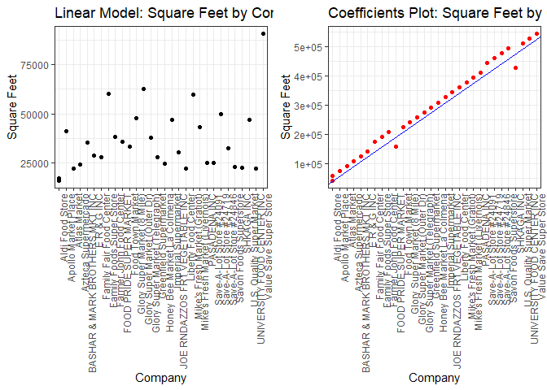

- The *Motivation* behind the linear model explored is to understand the relationship between the “SquareFeet” variable and the “Company” variable in the dataset. The code calculates the total square feet for each company, selects the top 30 companies with the highest total square feet, and then fits a linear regression model to examine how the square footage varies across different companies.

## Project 03

**Sample data visualization:**

*[The density distribution of maximum temperatures across the months of the year 2022]*

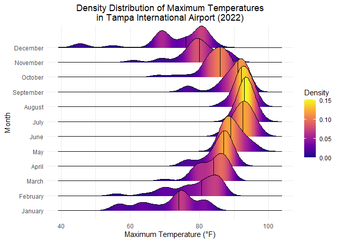

### Moving Forward

- During my exploration of data visualization, data storytelling, reproducible research, and related topics, I’ve gained a deeper understanding of the power and importance of effectively communicating data-driven insights. Here are some key reflections on what I’ve learned and my plans for further exploration:
- Data visualization as a storytelling tool: I’ve realized that data visualization is not just about creating aesthetically pleasing charts and graphs; it’s about telling a compelling story with data. Visualizations have the potential to engage and resonate with audiences, making complex information more accessible and understandable. Going forward, I want to continue honing my skills in designing meaningful and impactful visual narratives.
- The role of interactivity and user experience: Interactive visualizations offer a unique opportunity for users to explore data in a personalized and engaging manner. By allowing users to interact with visualizations, they can gain deeper insights and uncover patterns or trends that might otherwise remain hidden. I plan to delve further into interactive visualization techniques, including tools like D3.js, to create more immersive and informative experiences for users.
- Reproducible research for transparency and collaboration: Reproducible research is crucial for ensuring transparency, facilitating collaboration, and advancing scientific knowledge. I’ve learned the value of documenting my data analysis and visualization workflows, including code, data sources, and methodologies. In the future, I intend to explore reproducibility frameworks such as Jupyter Notebooks, R Markdown, or similar tools to make my work more accessible, transparent, and reproducible.
- Ethical considerations in data visualization: As data becomes more prevalent and influential, it is essential to address the ethical implications of data visualization. I’ve become more aware of the potential biases, misrepresentations, and unintended consequences that can arise in visualizing data. I aim to deepen my understanding of ethical practices and considerations in data visualization to ensure responsible and inclusive storytelling.
- Incorporating multidisciplinary approaches: Data visualization and storytelling draw upon various disciplines, including statistics, design, psychology, and communication. I’ve realized the importance of incorporating diverse perspectives and skills to create effective visualizations. Moving forward, I plan to explore interdisciplinary collaborations and learn from experts in fields such as graphic design, cognitive science, and human-computer interaction.

Overall, I’ve come to appreciate the power of data visualization and storytelling as essential tools for communicating insights, driving decision-making, and fostering understanding. I’m excited to continue exploring these topics, pushing the boundaries of visualization techniques, and contributing to the evolving field of data-driven communication.